# Effect of Genetic Variants on DEG with comparison to Satterstrom

## 1. Abstract

이 포트폴리오의 목적은 ’Single-cell genomics identifies cell type–specific molecular changes in autism’의 data4,5을 이용해서 **cell type 별로 satterstrom gene list와 비교하여 overlap되는 ASD의 DEG를 찾고, 이 DEG의 pLI score를 확인해서 Effect of Genetic Variants on ASD Risk**을 확인하는 것에 있다.

Satterstrom gene list와 비교를 한 이유는 DEG의 ASD risk 연관성 신뢰도를 높이고자 함이다. Satterstrom 2020은 cohort sample study에서 sample size도 매우 크고, 체계적으로 다방면의 분석을 진행하였다. rare and de novovariants defining을 먼저 하고, pLI score 뿐만 아니라 MPC(missensebadness, PolyPhen-2, constraint) score도 고려하며 Transmission and De Novo Association Test (TADA), ASDP, ASDNDD and DDD gene heterogeneity analyses, Genes in Recurrent Genomic Disorders (GD) 등의 분석을 통해 102개의 ASD을 얻었다. 따라서 이렇게 얻은 satterstrom gene list (102 ASD)는 유의성이 크다고 보아 비교 분석 대상으로 선정하였다.

먼저 ASD의 DEG fold change을 cell type 별로 보고, *sattterstrom gene*과 비교하여 이 data4 상의 DEG임과 동시에 *satterstorm gene*이기도 한 gene들을 찾는다. *satterstrom gene*과의 비교는 이를 통해 association with ASD 대한 신뢰도를 높이고자 함이다. 이렇게 찾은 특정 gene들의 pLI를 “Large-Scale Exome Sequencing Study Implicates Both Developmental and Functional Changes in the Neurobiology of Autism”의 supplemental data table 2에서 확인한다. 또한 이 “특정 gene”을 앞으로 gene with high reliablity, 즉 `HR_gene`이라고 한다.

이 때 pLI란 probability of loss-of-function intolerance의 줄임말로 LOF variants에 대한 불내증 지수를 나타낸다. pLI가 높을수록 LOF에 민감하여 ASD risk가 높아진다고 해석하고, 이에 대해 0.95를 기준으로 잡는다.

## 2. Data loading & analysis.

우선 raw data (excel file)과 이를 처리할 수 있는 packages을 불러온다.

```r
library(tidyverse)
library(dplyr)
library(ggplot2)
library(readxl)
library(ggrepel)
library(ggthemes)
library(cowplot)
data4 <- readxl::read_xls("aav8130_Data-S4.xls")

head(data4)
```

| Cell type | gene ID | Gene name | Gene biotype | Fold change | Sample fold change | q value | correlation (bulk mRNA/bulkized nuclear RNA) | Epilepsy DEG | gene group | SFARI gene | Satterstrom | Sanders | cell type-specific expression |
| --- | --- | --- | --- | --- | --- | --- | --- | --- | --- | --- | --- | --- | --- |
| L2/3 | ENSG00000116830 | TTF2 | protein_coding | -0.2263279 | -0.8440443 | 3.870510e-05 | 0.21598395220359112 | yes | group I | no | no | no | no |
| L2/3 | ENSG00000183486 | MX2 | protein_coding | -0.1589944 | -1.1595522 | 6.999077e-05 | -0.034721299759704047 | no | group I | no | no | no | no |
| L2/3 | ENSG00000138303 | ASCC1 | protein_coding | -0.1699755 | -0.4284487 | 1.172638e-04 | 0.35601883626631353 | no | group I | no | no | no | no |
| L2/3 | ENSG00000145451 | GLRA3 | protein_coding | 0.2458418 | 0.3968136 | 1.525338e-04 | 0.51335956747846367 | no | group V | no | no | no | no |
| L2/3 | ENSG00000099622 | CIRBP | protein_coding | -0.2184618 | -0.4513435 | 3.024188e-04 | 0.2473722042784588 | no | group III | no | no | no | no |
| L2/3 | ENSG00000141504 | SAT2 | protein_coding | -0.2356147 | -0.7958851 | 4.962561e-04 | 0.28799586697696894 | yes | group II | no | no | no | no |

이 중 `Cell type`, `Gene name`, `Fold change`, `q value`, `Satterstrom`의 정보만이 필요하기 때문에 tidy format으로 새롭게 지정해준다.

```r
d4 <- data4 %>% select(`Cell type`, `Gene name`, `Fold change`, `q value`, Satterstrom)
```

`Cell type`이 cell line에 대한 정보를 담고 있는데, ASD가 hetero geneous neurodevelopmental condition이라는 점에서 cell line 각각이 neuron인지 아닌지에 대한 정보도 추가로 담기로 한다.

```r
neuron = c("L2/3","L4","L5/6","L5/6-CC","Neu-mat","Neu-NRGN-I","Neu-NRGN-II","IN-PV","IN-SST","IN-VIP","IN-SV2C" )
d4 <- d4 %>% mutate(neuronal = ifelse(`Cell type` %in% neuron, "neuron", "non-neuron"))
d4_n <- d4 %>% filter(neuronal=="neuron")
d4_nn <- d4 %>% filter(neuronal=="non-neuron")
head(d4)
```

| Cell type | Gene name | Fold change | q value | Satterstrom | neuronal |
| --- | --- | --- | --- | --- | --- |
| L2/3 | TTF2 | -0.2263279 | 3.870510e-05 | no | neuron |
| L2/3 | MX2 | -0.1589944 | 6.999077e-05 | no | neuron |
| L2/3 | ASCC1 | -0.1699755 | 1.172638e-04 | no | neuron |
| L2/3 | GLRA3 | 0.2458418 | 1.525338e-04 | no | neuron |
| L2/3 | CIRBP | -0.2184618 | 3.024188e-04 | no | neuron |
| L2/3 | SAT2 | -0.2356147 | 4.962561e-04 | no | neuron |

`HR_gene`에 해당하는 d4 data와 pLI 정보를 합치기 위해 “Large-Scale Exome Sequencing Study Implicates Both Developmental and Functional Changes in the Neurobiology of Autism”의 supplemental data table 2를 `merge`해준다.

```r
d4_s = d4 %>% filter(Satterstrom=="yes") %>% rename('gene' = `Gene name`)
d4_s_gn = d4_s$gene
d4_sat = satterstrom_102ASD %>% filter(gene %in% d4_s_gn)
d4_s_sat = merge(d4_s, d4_sat, by = 'gene')
```

## 3. Visualization

d4 visualization을 통해 `Cell type`별로 `DEG`의 `fold change`와 `neuron`, `Satterstrom gene`에 대한 정보를 volcano plot에 담았다.

### 3.1 1st Plot - DEG Fold Change by Cell type (feat.Satterstrom)

```r
p1<- d4_n %>%
  ggplot(aes(x=`Fold change`, y= -log10(`q value`), col= `Cell type`)) +
  geom_point(size=1.0, alpha=0.8) +
  geom_vline(xintercept = 0.0, color="gray", size= 1.5) +
  geom_label_repel(data=d4_n %>% filter(Satterstrom=="yes"),aes(label=`Gene name`),size=3.5, nudge_x = 0.2, nudge_y = 0.1)+
  ggtitle("Neuron (n=458)")+
  xlim(c(1.0,-1.0))+
  ylab("-log10(q value)")+
  theme_tufte()+
  theme(axis.line = element_line(size = 1,colour = "black"))+
  theme(legend.position = "bottom",
        legend.background = element_rect(fill="lightblue",
                                  size=0.5, linetype="solid",
                                  colour ="darkblue"),
        legend.key.size = unit(3,'mm'),
        plot.title = element_text(size=20, face = "bold"),
        axis.title = element_text(size = 15))+
  guides(color=guide_legend(nrow = 2))

p2<- d4_nn %>%
  ggplot(aes(x=`Fold change`, y= -log10(`q value`), col= `Cell type`)) +
  geom_point(size=1.0, alpha=0.8)+
  geom_vline(xintercept = 0.0, color="gray", size= 1.5) +
  geom_label_repel(data=d4_nn %>% filter(Satterstrom=="yes"),aes(label=`Gene name`),size=3.5, nudge_x = 0.2, nudge_y = 0.1)+
  ggtitle("NonNeuron (n= 234)")+
  xlim(c(1.0,-1.0))+
  ylab("-log10(q value)")+
  theme_tufte()+
  theme(axis.line = element_line(size = 1,colour = "black"))+
  theme(legend.position ="bottom",
        legend.background = element_rect(fill="lightblue",
                                  size=0.5, linetype="solid",
                                  colour ="darkblue"),
        legend.key.size = unit(3,'mm'),
        plot.title = element_text(size=20, face = "bold"),
        axis.title = element_text(size = 15))+
  guides(color=guide_legend(nrow = 2))

plot_row <- plot_grid(p1,p2)



title <- ggdraw() +
  draw_label(
    "DEG Fold Change by Cell type (feat.Satterstrom) ",
    fontfamily = "serif",
    fontface = 'bold',
    color = '#0C1783',
    x = 0,
    hjust = 0,
    size = 20
  )
plot1 <-plot_grid(
  title, plot_row,
   ncol = 1,
  rel_heights = c(0.1, 1)
)
```

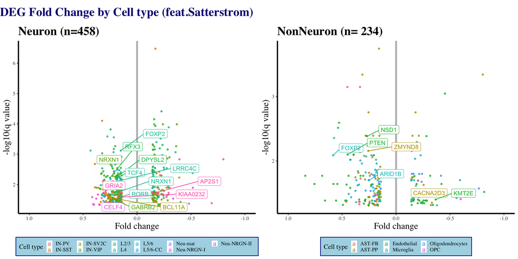

```r
plot1
```

### 3.2 2nd Plot - pLI of `HR_gene`

위의 volcaono plot label에서 확인할 수 있는 `HR_gene`의 pLI를 heatmap으로 visualization한다.

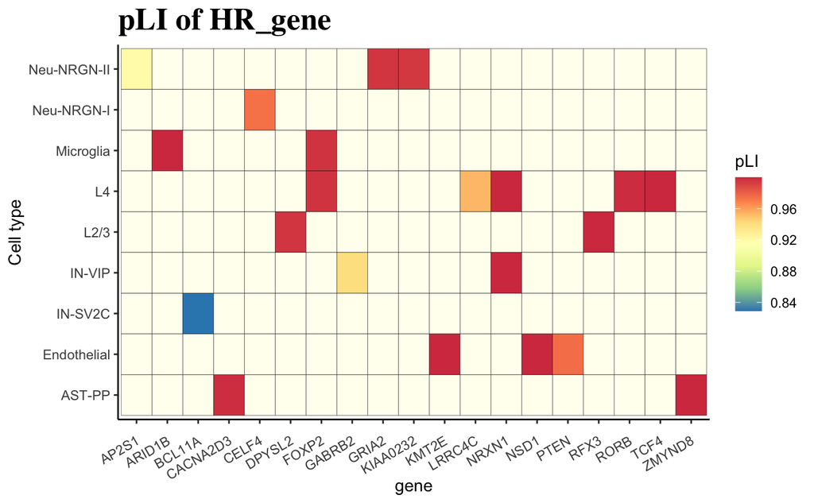

```r
rd <- d4_s_sat %>% select(`Cell type`, gene, pLI)
rd <- rd %>% pivot_wider(names_from = gene, values_from = pLI)
rd <- pivot_longer(rd,!`Cell type`, names_to = 'gene', values_to = 'pLI')

plot2 <- ggplot(rd, aes(x=gene, y=`Cell type`, fill=pLI)) +
  geom_tile(color="black")+
  theme_classic() +
  theme(axis.text.x = element_text(angle = 30, vjust = 0.8, hjust = 1))+
  scale_fill_distiller(palette = "Spectral", na.value = "ivory")+
  ggtitle('pLI of HR_gene')+
  theme(plot.title = element_text(family = "serif", face = "bold", size = 20))

plot2
```

cell type 별로 `HR_gene`의 pLI score를 색깔을 통해 알 수 있다.

## 4. Conclusion

1st Plot을 통해 neuron/ non neuron으로 나눠 cell type 별로 DEG의 fold change와 Satterstrom gene에 해당하는 `HR_gene`을 확인할 수 있다. Neuronal cell line의 경우 *DPYSL2*, *RFX3*, *FOXP2*, *TCF4*, *LRRC4C*, *NRXN1*, *RORB*, *CELF4*, *AP2S1*, *GRIA2*, *KIAA0232*, *NRXN1*, *GABRB2*, *BCL11A* 이 있고, Non neuronal cell line의 경우 *FOXP2*, *ARID1B*, *ZMYND8*, *CACNA2D3*, *NSD1*, *PTEN*, *KMT2E* 이 있다.

2nd Plot을 통해 `HR_gene` 21개 (같은 gene이라 하더라도 cell type이 다르면 각각 개수를 세었을 때) 중 18개가 pLI score 0.95 이상임을 볼 수 있다. 이를 통해 `HR_gene` 대부분이 LOF에 intolerant 하다는 것을 알게 되었다.

*CACNA2D3* 의 경우 흥미롭게도 Calcium channel encoding gene임에도 불구하고 Non neuronal cell line인 AST-PP (protploasmic astrocyte)의 `HR_gene`이다. astrocyte는 자극에 반응하여 세포 간 Ca2 + 파동을 장거리 전파하고 neuron과 유사하게 Ca2 + 의존적 방식으로 gliotransmitter를 방출하는데 이를 통해 neuron에 신호를 보낸다. 즉, astrocyte와 neuron 간 신호 전달에 Ca2+가 중요한 역할을 하고 있기 때문에 Calcium channel encoding gene인 *CACNA2D3* 에 risk가 큰 variants가 있을 경우 nuerotransmission에 이상이 생길 것이다.

## 5. Feedback

mid portfolio에서는 satterstrom이 아닌 SFARI gene과의 overlap gene을 분석하였다. 하지만 SFARI gene은 reports 횟수로 등급을 나누어 score을 부여하기 때문에, SAFRI gene보다는 더 유의성이 높은 satterstrom을 DEG 신뢰도를 높이기 위한 일종의 교차 검정용으로 적합한 data라고 생각하였다.

기존의 scatter plot, bar plot을 삭제하고 volcano plot과 heatmap을 사용하여 단조로움을 줄이고, 정렬 및 배치를 간결하게 바꾸고자 하였다.

또한 `HR_gene`의 단순한 mutation type이 아닌 pLI를 분석함으로써 Effect of Genetic Variants on ASD Risk을 알 수 있다.